[figure not shown]

#### Inferência Estatística para Ciência de Dados

# Construindo um classificador binário

Construindo um classificador binário

Prof. Wagner Hugo Bonat

2019-03-29

# 1 Introdução

Classificadores binários são ferramentas populares em estatística e aprendizagem de máquina. Dentre os vários classificadores a regressão logística é um dos mais simples e populares. O modelo de regressão logística se aplica a uma variável de interesse do tipo binária. As aplicações são as mais diversas possíveis cobrindo desde aplicações na indústria onde itens são classificados como conforme ou não-conforme até a medicina onde se estuda a presença ou ausência de uma certa doença e como isso se relaciona com hábitos de vida dos pacientes, tais como, sexo, idade, tabagismo entre outros.

O objetivo deste material é discutir apenas os aspectos matemáticos relacionados a construção de um classificador binário. Mais especificamente nos vamos discutir como apartir da ideia simples do modelo de regressão linear múltipla nos chegamos ao modelo de regressão logística. Os aspectos práticos desta técnica serão discutidos na disciplina de Modelagem Estatística.

A especificação e implementação do modelo de regressão logística envolve uma série de conhecimentos em métodos matemáticos que começam em funções passa por cálculo diferencial onde a necessidade de resolver um sistema não-linear fica evidente. No processo de solução de sistemas não-lineares operações com vetores, matrizes, a obtenção de inversas e de forma mais geral a solução de sistemas lineares aparece de forma proeminente. Entretanto, todo o processo de ajuste ou treinamento do modelo pode ser descrito como um simples problema de otimização não-linear.

## 1.1 Descrição do problema

Suponha que temos um conjunto de observações $y_i$ com $i = 1, \ldots, n$ de uma variável de interesse do tipo binária, ou seja, $y_i \in \{0, 1\}$. O objetivo pode ser descrever o relacionamento de $y_i$ com um conjunto de variáveis explanatórias, digamos $\boldsymbol{x}_{ij}$, ou mesmo apenas classificar uma nova observação em um dos grupos $0$ ou $1$ de acordo com os valores das variáveis explanatórias.

Como um exemplo de aplicação, suponha que temos um conjunto de dados com três colunas: renda do usuário (por mil), anos de experiência do usuário e se o usuário é assinante ou não. Nosso, objetivo é descrever como as variáveis explanatórias, neste caso renda e anos de experiência do usuário estão relacionados com o fato dele ser ou não um assinante . Uma vez identificado tal relacionamento, podemos usá-lo para predizer se um novo usuário será ou não assinante , bem como, identificar dentro da base usuários que podem se interessar pela assinatura . O resultado também pode ser usado para orientar campanhas de entre outros. A base de dados é fornecida no arquivo *reg_log.txt* e as primeiras linhas são mostradas abaixo.

```
# Loading required package: tweedie
#   Premium    Renda Anos
# 1       0 18.90256    4
# 2       1 38.66267    7
# 3       1 82.16108    4
# 4       1 22.34817    8
# 5       1 36.13398    9
# 6       0 52.61761    2
```

Podemos visualizar os dados plotando as variáveis explanatórias e marcar com diferentes símbolos usuários e não .

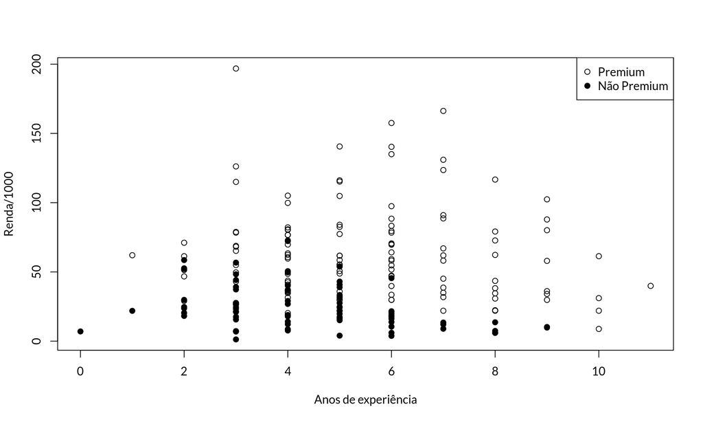

## 1.2 Função perda quadrática para variáveis binárias

A ideia de construir um classificador é similar ao modelo de regressão linear múltipla, ou seja, queremos minizar uma certa distância entre os dados $y_i$ e nosso modelo linear $\beta_0 + \beta_1 renda_i + \beta_2 anos_i$. Sendo assim, uma primeira tentativa óbvia é minimizar
$$SQ(\boldsymbol{\beta}) = \sum_{i=1}^n (y_i - (\beta_0 + \beta_1 renda_i + \beta_2 anos_i))^2.$$
Isso pode ser feito facilmente em *R* uma vez que temos vários otimizadores numéricos disponíveis. O primeiro passo é escrever a função objetivo:

```r
f_ols <- function(par, y, renda, anos) {
  mu <- par[1] + par[2]*renda + par[3]*anos
  SQ <- sum( (y - mu)^2 )
  return(SQ)
}
```

O segundo passo consiste em otimizar a função objetivo. Por simplicidade vamos usar um algoritmo numérico, porém lembre-se que neste caso temos expressões fechadas disponíveis.

```r
fit_ols <- optim(par = c(0,0,0), fn = f_ols, y = dados$Premium,
                 renda = dados$Renda, anos = dados$Anos)
fit_ols
# $par
# [1] -0.001263985  0.007946350  0.048480489
#
# $value
# [1] 29.83881
#
# $counts
# function gradient
#      124       NA
#
# $convergence
# [1] 0
#
# $message
# NULL
```

O algoritmo convergiu e forneceu o vetor de $\beta$’s que minimiza a soma de quadrados. Podemos agora usar estes valores para predizer se um usuário é ou não dado sua renda e anos de experiência. Neste caso, apenas como exemplo vamos predizer os mesmos usuários que foram usados para ajustar/treinar o modelo. Note que isso, também fornece uma indicação se o modelo tem um bom poder de predição. Entretando, na prática é mais usual separar a base em treino e teste e predizer os usuários na base teste. A predição é bastante simples entramos com a renda e anos de estudo e saímos com uma predição para $y_i$.

```r
preditos <- fit_ols$par[1] + fit_ols$par[2]*dados$Renda + fit_ols$par[3]*dados$Anos
```

Vamos plotar os preditos contra os observados para verificar a performance do nosso modelo.

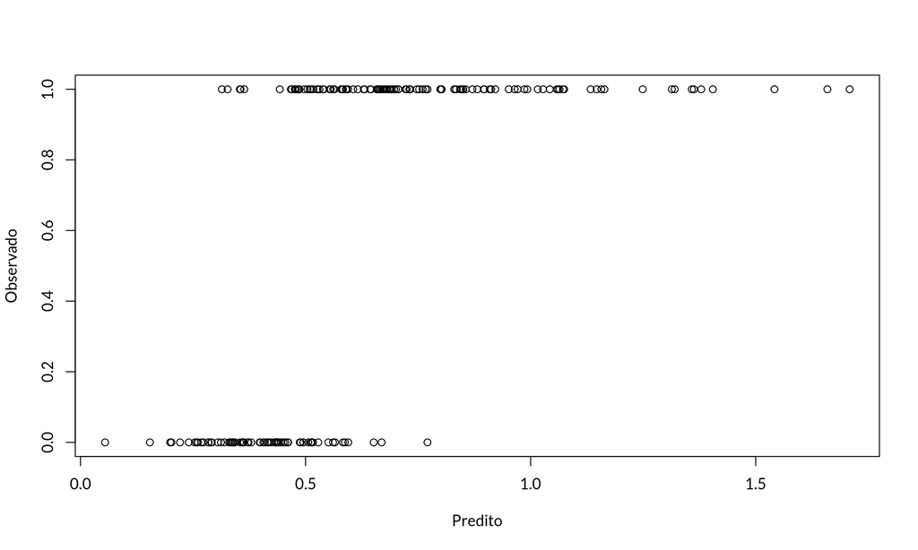

Apesar de ser possível essa abordagem leva a algumas incoveniências. Por exemplo, o ideal seria que a previsão fossem $0$ ou $1$ refletindo se o novo usuário será ou não um assinante . No entanto, vimos que o modelo fornece preditos maiores que $1$ e pode potencialmente fornecer preditos negativos para usuários com pouca experiência e renda menor. Neste sentido, a interpretação do modelo não é clara e não reflete de forma fidedigna a realidade.

## 1.3 Melhorando o modelo

Existem na literatura diversas funções que tem tal propriedade. Uma escolha popular é a função logística dada por:
$$f(x) = \frac{1}{1+e^{-x}},$$
cujo gráfico é apresentado abaixo.

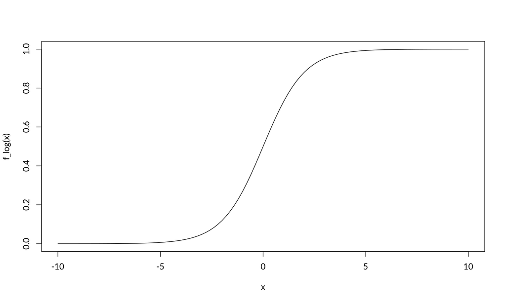

Com a função logística em mãos podemos rescrever nossa função objetivo como

$$SQ_{logit}(\boldsymbol{\beta}) = \sum_{i=1}^n \left(y_i - \frac{1}{(1+ e^{-(\beta_0 + \beta_1 renda_i + \beta_2 anos_i)} )} \right)^2.$$
Novamente, podemos facilmente otimizar essa função objetivo, ou seja, encontrar $\beta_0$, $\beta_1$ e $\beta_2$ que tornam $SQ_{logit}$ o menor possível. Novamente escrevemos a função objetivo

```r
f_logit <- function(par, y, renda, anos) {
  mu <- 1/(1+ exp(- (par[1] + par[2]*renda + par[3]*anos)))
  SQ_logit <- sum( (y - mu)^2 )
  return(SQ_logit)
}
```

Otimizamos numéricamente.

```r
fit_logit_ols <- optim(par = c(0,0,0), fn = f_logit, y = dados$Premium,
                 renda = dados$Renda, anos = dados$Anos)
fit_logit_ols
# $par
# [1] -6.6424785  0.1285065  0.5390356
#
# $value
# [1] 21.35787
#
# $counts
# function gradient
#      220       NA
#
# $convergence
# [1] 0
#
# $message
# NULL
```

Plotando os preditos contra os observados.

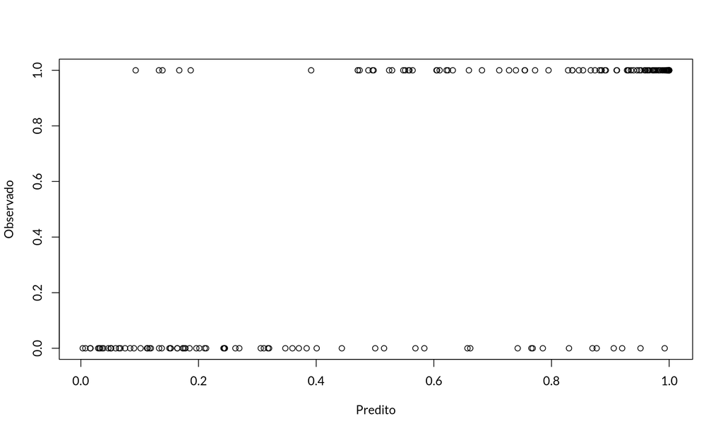

Neste caso fica claro que nosso modelo só prediz valores no intervalo unitário como gostaríamos. Claramente quanto maior é o preditor maior é a chance dos observados serem $1$ como queríamos.

## 1.4 Melhorando a função objetivo

Apesar de melhor que a estratégia anterior, essa abordagem ainda faz uso uso da perda quadrática. Isso significa assumimos que nossos erros são simétricos ao redor da curva ajustada, neste caso a logística. Entretanto, tal suposição não reflete o fato de que nas caudas da curva os erros não podem ser simétricos. Por exemplo, no extremo da cauda esquerda (baixa renda e pouca experiência) só podemos errar para mais, enquanto que no extremo da cauda direita só podemos errar para menos. Assim, seria interessante termos uma função objetivo que melhor represente nossa intuição.

Para construir uma função objetivo que atenda a nossa intuição, podemos recorrer a uma distribuição de probabilidade adequada para dados binários. A distribuição Bernoulli modela variáveis aleatórias que podem assumir apenas dois valores $0$ ou $1$, sendo $1$ chamado de sucesso e $0$ de fracasso. A distribuição Bernoulli, tem a seguinte função de probabilidade
$$P(Y = y_i) = p^{y_i}(1-p)^{1-y_i},$$
onde $p$ é a probabilidade de sucesso, ou seja, $P(Y = 1) = p$.

Para um conjunto de $n$ observações cada uma sendo binária, podemos usar o produto das funções de probabilidade como uma função objetivo a ser maximizada neste caso. Note que a função de probabilidade fornece a probabilidade da variável aleatória assumir um certo valor dado um valor para $p$. Uma vez que temos os dados observados $y_i$ a única quantidade desconhecida é o valor de $p$. E a nossa função objetivo fornece a probabilidade de observar os dados REALMENTE observados $y_i$ caso o valor do $p$ seja um valor fixado. O objetivo é encontrar $\hat{p}$ que maximiza essa probabilidade, ou seja, de observar o que você REALMENTE observou. Essa é a idéia por traz de um dos métodos mais populares e poderosos de estimação chamado método de máxima verossimilhança que vamos ver no decorrer do curso.

Como $p$ é a probabilidade de sucesso, neste caso o usuário ser assinante , podemos descrever tal probabilidade de acordo com as características dos usuários, neste caso renda e anos de experiência. Uma vez que $p$ é uma probabilidade só pode assumir valores no intervalo unitário, assim usando a função logística podemos descrever/modelar $p$ pela seguinte equação:

$$p_i = \frac{1}{1+e^{-(\beta_0 + \beta_1 renda_i + \beta_2 anos)}}.$$
Substituindo na equação acima chegamos a seguinte função objetivo
$$L(\boldsymbol{\beta}) = \prod_{i=1}^n p_i^{y_i}(1-p_i)^{1-y_i}.$$

Entretanto, em termos computacionais usar o produto de números entre $0$ e $1$ é incoveniente, porque conforme o número de termos sendo multiplicado cresce a função objetivo vai rapidamente para zero. Assim, é mais conveniente computacionalmente usar o logaritmo do produto das funções de probabilidade o que resulta na seguinte função objetivo:
$$l(\boldsymbol{\beta}) = \sum_{i=1}^n y_i \log(p_i) + (1-y_i)\log(1-p_i).$$
Essa função objetivo reflete o fato dos erros não serem simétricos ao redor do modelo ajustado e na sequência vamos ver como também fornece uma série de propriedades interessantes do ponto de vista de estatística.

Para finalizar, vamos implementar essa nova função objetivo e otimizá-la numéricamente. A função em *R* fica dada por

```r
f_ber <- function(par, y, renda, anos) {
  eta = par[1] + par[2]*renda + par[3]*anos
  p <- 1/(1+exp(-eta))
  out <- sum(y*log(p) + (1-y)*log(1-p))
  return(out)
}
```

Fazendo a otimização numericamente, temos

```r
fit_ber <- optim(par = c(0,0,0), fn = f_ber, y = dados$Premium,
                 renda = dados$Renda, anos = dados$Anos,
                 control = list(fnscale = -1))
fit_ber
# $par
# [1] -6.1193677  0.1124951  0.5039379
#
# $value
# [1] -68.07937
#
# $counts
# function gradient
#      166       NA
#
# $convergence
# [1] 0
#
# $message
# NULL
```

Note que neste caso temos que maximizar a função objetivo, por isso usamos o argumento adicional da função *optim()* *fnscale = -1* para tornar o problema de minimização, uma vez, que por *default* a função *optim()* minimiza a função objetivo. Podemos, novamente calcular os preditos usando esse novo modelo.

[figure not shown]

Caso fosse de interesse, podemos até comparar os preditos obtidos por cada uma das abordagens. Por exemplo,

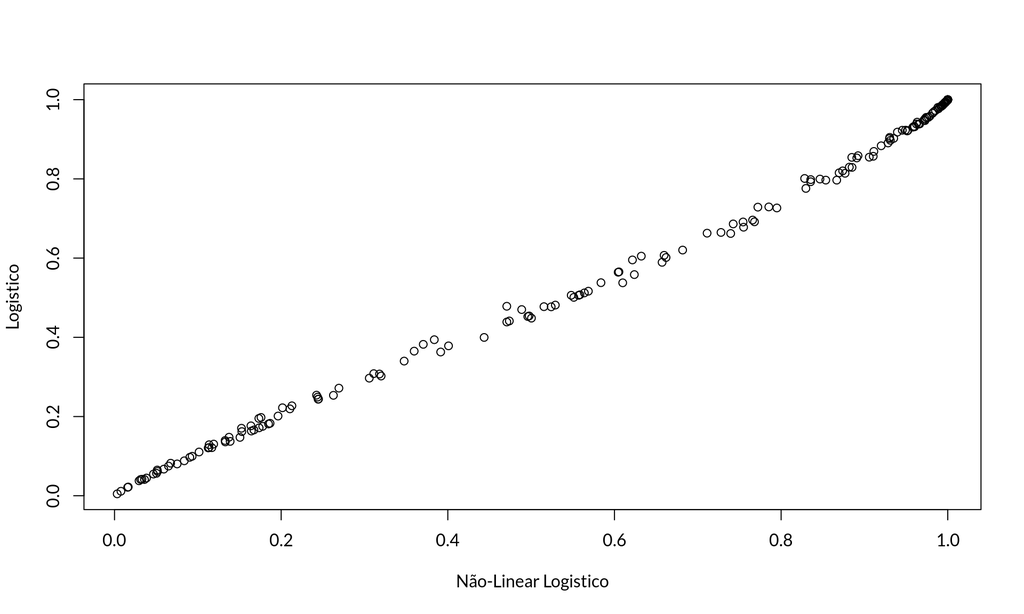

Neste caso, vemos uma grande similaridade entre os dois classificadores. Para classificar, podemos definir um limiar por exemplo, se $\hat{p} < l1$ dizemos que o usuário não é e caso contrário, ou seja, se $\hat{p} > l1$ o usuário é .

É importante notar que nos fomos passo-a-passo tornando nosso modelo mais condizente com a realidade e consequentemente atendendo às nossas intuições de como a realidade deve ser. O uso da função Bernoulli para construir a função objetivo combinada com a função logística é o que se denomina de modelo de regressão logística na literatura estatística.

## 1.5 Melhorando o algoritmo de ajuste

Uma vez que o modelo foi definido e a função objetivo escolhida o processo de treinamento ou ajuste do modelo consiste em um problema de otimização numérica. Até o momento, nos simplesmente usamos otimizadores genéricos já implementados na função *optim()* do software *R*.

Como já discutimos a otimização de uma função pode ser feita de diversas formas. Nos exemplos anteriores nos usamos o algoritmo de Nelder-Mead que não depende de derivadas. O algoritmo de Newton é o mais eficiente em termos de número de iterações para atingir a convergência. Sendo assim, vamos agora discutir como implementar o algoritmo de Newton para o modelo de regressão logística. Lembre-se que a função a ser otimizada é

$$l(\boldsymbol{\beta}) = \sum_{i=1}^n y_i \log(p_i) + (1-y_i)\log(1-p_i).$$

O algoritmo de Newton trabalha com a seguinte equação de iteração

$$\boldsymbol{\beta^{(i+1)}} = \boldsymbol{\beta^{(i)}} - \mathbf{J(\boldsymbol{\beta^{(i)}})}^{-1} l'(\boldsymbol{\beta^{(i)}}),$$
onde $\mathbf{J(\boldsymbol{\beta^{(i)}})}$ é uma matriz hessiana de dimensão $3 \times 3$ e $l'(\boldsymbol{\beta^{(i)}})$ é vetor gradiente de dimensão $3 \times 1$. Precisamos, de um vetor inicial $\boldsymbol{\beta}^{(1)}$ para o vetor de parâmetros $3 \times 1$ no caso do nosso exemplo. O vetor gradiente é dado por
$$l'(\boldsymbol{\beta^{(i)}}) = \left(\frac{\partial l'(\boldsymbol{\beta})}{\partial \beta_0},\frac{\partial l'(\boldsymbol{\beta})}{\partial \beta_1}, \frac{\partial l'(\boldsymbol{\beta})}{\partial \beta_2} \right)^{\top}.$$
Para obter cada uma das entradas do vetor gradiente usamos as regras básicas de derivação associadas a regra da cadeia. Para simplificar a notação, seja $\eta_i = \beta_0 + \beta_1 renda_i + \beta_2 Anos_i$. Assim, tem-se
$$\frac{\partial l'(\boldsymbol{\beta})}{\partial \beta_j} = \frac{\partial l'(\boldsymbol{\beta})}{\partial p} \frac{\partial p}{\partial \eta} \frac{\partial \eta}{\partial \beta_j}, \quad \text{para} \quad j = 1, 2, 3.$$
Obtendo cada uma das entradas, tem-se
$$\frac{\partial l'(\boldsymbol{\beta})}{\partial p} = \frac{\partial}{\partial p} y_i \log(p_i) + (1-y_i)\log(1-p_i) = \frac{y_i}{p_i} - \frac{(1-y_i)}{(1-p_i)} = \frac{y_i - p_i}{p_i(1-p_i)}.$$

Derivando o $p$ em relação ao $\eta$, tem-se

$$\frac{\partial p}{\partial \eta} = \frac{\partial}{\partial \eta} \frac{1}{1+ e^{-\eta}} = \frac{e^{-\eta}}{(1+e^{-\eta})^2} = p_i(1-p_i).$$
Derivando $\eta$ em relação aos $\beta$’s temos
$$\frac{\partial \eta}{\beta_0} = 1, \quad \frac{\partial \eta}{\beta_1} = renda_i \quad \text{e} \quad \frac{\partial \eta}{\beta_2} = anos_i.$$
Finalmente, temos o vetor gradiente
$$l'(\boldsymbol{\beta^{(i)}}) = \left(\sum_{i=1}^n (y_i - p_i)1, \sum_{i=1}^n (y_i - p_i)renda_i, \sum_{i=1}^n (y_i - p_i)anos_i \right)^{\top}.$$

Usando cálculos similares, podemos obter a matriz hessiana. Lembre-se, não deixe as derivadas te assustar, use um software de matemática simbólica caso não se sinta comfortável com os resultados.

$$\mathbf{J(\boldsymbol{\beta})} = -
\begin{bmatrix}
p_i(1-p_i)1 & p_i(1-p_i)renda_i & p_i(1-p_i)anos_i \\
p_i(1-p_i)renda_i & p_i(1-p_i)renda_i^2 & p_i(1-p_i)renda_i anos_i \\
p_i(1-p_i)anos_i & p_i(1-p_i)renda_i anos_i & p_i(1-p_i)anos_i^2
\end{bmatrix}.$$

Uma vez obtidos o gradiente e o hessiano, podemos implementar ambas funções em *R*.

```r
# Gradiente
gradiente <- function(par, y, renda, anos) {
  eta = par[1] + par[2]*renda + par[3]*anos
  p <- 1/(1+exp(-eta))
  db0 <- sum((y - p))
  db1 <- sum((y-p)*renda)
  db2 <- sum((y-p)*anos)
  out <- c(db0, db1, db2)
  return(out)
}
# Hessiana
hessiano <- function(par, y, renda, anos) {
  J <- matrix(NA, ncol = 3, nrow = 3)
  eta = par[1] + par[2]*renda + par[3]*anos
  p <- 1/(1+exp(-eta))
  J[1,1] <- sum(p*(1-p))
  J[1,2] <- sum(p*(1-p)*renda)
  J[1,3] <- sum(p*(1-p)*anos)
  J[2,1] <- sum(p*(1-p)*renda)
  J[2,2] <- sum(p*(1-p)*(renda^2) )
  J[2,3] <- sum(p*(1-p)*renda*anos)
  J[3,1] <- sum(p*(1-p)*anos)
  J[3,2] <- sum(p*(1-p)*(renda*anos))
  J[3,3] <- sum(p*(1-p)*(anos^2))
  return(-J)
}
```

O método de Newton foi discutido e implementado, assim podemos usar a nossa função.

```r
newton <- function(fx, jacobian, x1, tol = 1e-04, max_iter = 10, ...) {
  solucao <- matrix(NA, ncol = length(x1), nrow = max_iter)
  solucao[1,] <- x1
  for(i in 1:max_iter) {
    J <- jacobian(solucao[i,], ...)
    grad <- fx(solucao[i,], ...)
    solucao[i+1,] = solucao[i,] - solve(J, grad)
    if( sum(abs(solucao[i+1,] - solucao[i,])) < tol) break
  }
  return(solucao)
}
```

Otimizando a função, tem-se

```
#            [,1]       [,2]      [,3]
#  [1,]  0.000000 0.00000000 0.0000000
#  [2,] -2.004560 0.03178176 0.1938505
#  [3,] -3.622509 0.06384417 0.3023678
#  [4,] -5.112017 0.09318818 0.4179397
#  [5,] -5.942349 0.10917130 0.4881873
#  [6,] -6.116275 0.11242702 0.5036863
#  [7,] -6.122200 0.11253511 0.5042327
#  [8,] -6.122206 0.11253523 0.5042333
#  [9,]        NA         NA        NA
# [10,]        NA         NA        NA
```

Pelo traço do algoritmo é fácil verificar a convergência. Recomendo como exercício implementar o mesmo modelo usando o algoritmo gradiente descendente e o método quasi-Newton BFGS.

[output not shown]